# Indian Food Cookbook

Emily, Ellyn, Rachel, Gabe

2/17/2022

#Background of Project

Welcome to the Exploring India Cookbook, this an e-cook book that will allow you to select different dishes you would like to make depending on your diet, amount of time you have, the course you would like to make, or based on the region.

This project is separated into three parts: Section 1: Loading and Cleaning the Data Section 2: Questions about the data Section 3: Exploring India Cookbook App

##Section 1:

This section illustrates how we loaded the data, assessed the data structure, and cleaned the data. *Load Library*

```r
library(tidyverse)
library(RColorBrewer)
library(paletteer)
library(janitor)
library(here)
library(naniar)
library(gapminder)
library(shinydashboard)
library(ggthemes)
library(shiny)
```

1. Load the data.

```r
indian_food<- read_csv(here("indian_food_data.csv"))%>% clean_names()
```

2. Structure of the data.

```r
glimpse(indian_food)
```

```
## Rows: 255
## Columns: 9
## $ name           <chr> "Balu shahi", "Boondi", "Gajar ka halwa", "Ghevar", "Gu~
## $ ingredients    <chr> "Maida flour, yogurt, oil, sugar", "Gram flour, ghee, s~
## $ diet           <chr> "vegetarian", "vegetarian", "vegetarian", "vegetarian",~
## $ prep_time      <dbl> 45, 80, 15, 15, 15, 10, 10, 10, 20, 10, 10, 5, 20, 10, ~
## $ cook_time      <dbl> 25, 30, 60, 30, 40, 50, 50, 20, 30, 40, 40, 5, 30, 30, ~
## $ flavor_profile <chr> "sweet", "sweet", "sweet", "sweet", "sweet", "sweet", "~
## $ course         <chr> "dessert", "dessert", "dessert", "dessert", "dessert", ~
## $ state          <chr> "West Bengal", "Rajasthan", "Punjab", "Rajasthan", "Wes~
## $ region         <chr> "East", "West", "North", "West", "East", "East", "North~
```

```r
summary(indian_food)
```

```
##      name           ingredients            diet             prep_time
##  Length:255         Length:255         Length:255         Min.   : -1.00
##  Class :character   Class :character   Class :character   1st Qu.: 10.00
##  Mode  :character   Mode  :character   Mode  :character   Median : 10.00
##                                                           Mean   : 31.11
##                                                           3rd Qu.: 20.00
##                                                           Max.   :500.00
##    cook_time      flavor_profile        course             state
##  Min.   : -1.00   Length:255         Length:255         Length:255
##  1st Qu.: 20.00   Class :character   Class :character   Class :character
##  Median : 30.00   Mode  :character   Mode  :character   Mode  :character
##  Mean   : 34.53
##  3rd Qu.: 40.00
##  Max.   :720.00
##     region
##  Length:255
##  Class :character
##  Mode  :character
##
##
##
```

What are the variables?

```r
names(indian_food)
```

```
## [1] "name"           "ingredients"    "diet"           "prep_time"
## [5] "cook_time"      "flavor_profile" "course"         "state"
## [9] "region"
```

Dealing with NA’s

*NA’s in data is symbolized by a “-1”*

```r
indian_food<-indian_food%>%
  na_if("-1")
```

Counting Number of NA’s

```r
naniar::miss_var_summary(indian_food)
```

| variable | n_miss | pct_miss |
| --- | --- | --- |
| prep_time | 30 | 11.764706 |
| flavor_profile | 29 | 11.372549 |
| cook_time | 28 | 10.980392 |
| state | 24 | 9.411765 |
| region | 14 | 5.490196 |
| name | 0 | 0.000000 |
| ingredients | 0 | 0.000000 |
| diet | 0 | 0.000000 |
| course | 0 | 0.000000 |

*Split Ingredients Into Their Own Row*

We noticed that the ingredients were listed in one row, so we separated them into their own rows.

```r
indian_food<-indian_food%>%
  mutate_all(tolower)%>%
  transform(ingredients=str_split(ingredients,","))%>%
  unnest(ingredients)
indian_food
```

| name | ingredients | diet | prep_time | cook_time | flavor_profile | course | state | region |
| --- | --- | --- | --- | --- | --- | --- | --- | --- |
| balu shahi | maida flour | vegetarian | 45 | 25 | sweet | dessert | west bengal | east |
| balu shahi | yogurt | vegetarian | 45 | 25 | sweet | dessert | west bengal | east |
| balu shahi | oil | vegetarian | 45 | 25 | sweet | dessert | west bengal | east |
| balu shahi | sugar | vegetarian | 45 | 25 | sweet | dessert | west bengal | east |
| boondi | gram flour | vegetarian | 80 | 30 | sweet | dessert | rajasthan | west |
| boondi | ghee | vegetarian | 80 | 30 | sweet | dessert | rajasthan | west |
| boondi | sugar | vegetarian | 80 | 30 | sweet | dessert | rajasthan | west |
| gajar ka halwa | carrots | vegetarian | 15 | 60 | sweet | dessert | punjab | north |
| gajar ka halwa | milk | vegetarian | 15 | 60 | sweet | dessert | punjab | north |
| gajar ka halwa | sugar | vegetarian | 15 | 60 | sweet | dessert | punjab | north |

[output cut: 1126 more lines]

Adding Total Cook Time column which combines cook time and prep time.

```r
indian_food<-indian_food%>%
  mutate(total_cook_time=as.numeric(cook_time)+as.numeric(prep_time))
indian_food
```

| name | ingredients | diet | prep_time | cook_time | flavor_profile | course | state | region | total_cook_time |
| --- | --- | --- | --- | --- | --- | --- | --- | --- | --- |
| balu shahi | maida flour | vegetarian | 45 | 25 | sweet | dessert | west bengal | east | 70 |
| balu shahi | yogurt | vegetarian | 45 | 25 | sweet | dessert | west bengal | east | 70 |
| balu shahi | oil | vegetarian | 45 | 25 | sweet | dessert | west bengal | east | 70 |
| balu shahi | sugar | vegetarian | 45 | 25 | sweet | dessert | west bengal | east | 70 |
| boondi | gram flour | vegetarian | 80 | 30 | sweet | dessert | rajasthan | west | 110 |
| boondi | ghee | vegetarian | 80 | 30 | sweet | dessert | rajasthan | west | 110 |
| boondi | sugar | vegetarian | 80 | 30 | sweet | dessert | rajasthan | west | 110 |
| gajar ka halwa | carrots | vegetarian | 15 | 60 | sweet | dessert | punjab | north | 75 |
| gajar ka halwa | milk | vegetarian | 15 | 60 | sweet | dessert | punjab | north | 75 |
| gajar ka halwa | sugar | vegetarian | 15 | 60 | sweet | dessert | punjab | north | 75 |

[output cut: 1126 more lines]

##Section Two: Questions about the data. 1. Does it take more or less time to cook vegetarian versus non-vegetarian dishes? ELLYN

```r
indian_food_together<- read_csv(here("indian_food_data.csv"))%>% clean_names()
indian_food_together <- indian_food_together %>%
  mutate_all(tolower)

indian_food_together <-indian_food_together%>%
  na_if("-1")

indian_food_together <- indian_food_together%>%
  mutate(cook_time=as.numeric(cook_time), prep_time=as.numeric(prep_time)) %>%
  mutate(total_cook_time=cook_time+prep_time)


indian_food_together
```

| name | ingredients | diet | prep_time | cook_time | flavor_profile | course | state | region | total_cook_time |
| --- | --- | --- | --- | --- | --- | --- | --- | --- | --- |
| balu shahi | maida flour, yogurt, oil, sugar | vegetarian | 45 | 25 | sweet | dessert | west bengal | east | 70 |
| boondi | gram flour, ghee, sugar | vegetarian | 80 | 30 | sweet | dessert | rajasthan | west | 110 |
| gajar ka halwa | carrots, milk, sugar, ghee, cashews, raisins | vegetarian | 15 | 60 | sweet | dessert | punjab | north | 75 |
| ghevar | flour, ghee, kewra, milk, clarified butter, sugar, almonds, pistachio, saffron, green cardamom | vegetarian | 15 | 30 | sweet | dessert | rajasthan | west | 45 |
| gulab jamun | milk powder, plain flour, baking powder, ghee, milk, sugar, water, rose water | vegetarian | 15 | 40 | sweet | dessert | west bengal | east | 55 |
| imarti | sugar syrup, lentil flour | vegetarian | 10 | 50 | sweet | dessert | west bengal | east | 60 |
| jalebi | maida, corn flour, baking soda, vinegar, curd, water, turmeric, saffron, cardamom | vegetarian | 10 | 50 | sweet | dessert | uttar pradesh | north | 60 |
| kaju katli | cashews, ghee, cardamom, sugar | vegetarian | 10 | 20 | sweet | dessert | NA | NA | 30 |
| kalakand | milk, cottage cheese, sugar | vegetarian | 20 | 30 | sweet | dessert | west bengal | east | 50 |
| kheer | milk, rice, sugar, dried fruits | vegetarian | 10 | 40 | sweet | dessert | NA | NA | 50 |

[output cut: 245 more lines]

```r
indian_food_together %>%
  filter(!is.na(total_cook_time)) %>%
 group_by(diet) %>%
summarize(mean_total_time = mean(total_cook_time))
```

| diet | mean_total_time |
| --- | --- |
| non vegetarian | 81.84211 |
| vegetarian | 73.39806 |

```r
v_nv <- indian_food_together %>%
   filter(!is.na(total_cook_time)) %>%
  group_by(diet) %>%
 summarize(mean_total_time = mean(total_cook_time),
          min_total_time = min(total_cook_time),
          max_total_time = max(total_cook_time))
v_nv
```

| diet | mean_total_time | min_total_time | max_total_time |
| --- | --- | --- | --- |
| non vegetarian | 81.84211 | 20 | 270 |
| vegetarian | 73.39806 | 10 | 730 |

```r
v_nv_long <- v_nv%>%
pivot_longer(-diet, names_to ="time", values_to="cook_time")
v_nv_long
```

| diet | time | cook_time |
| --- | --- | --- |
| non vegetarian | mean_total_time | 81.84211 |
| non vegetarian | min_total_time | 20.00000 |
| non vegetarian | max_total_time | 270.00000 |
| vegetarian | mean_total_time | 73.39806 |
| vegetarian | min_total_time | 10.00000 |
| vegetarian | max_total_time | 730.00000 |

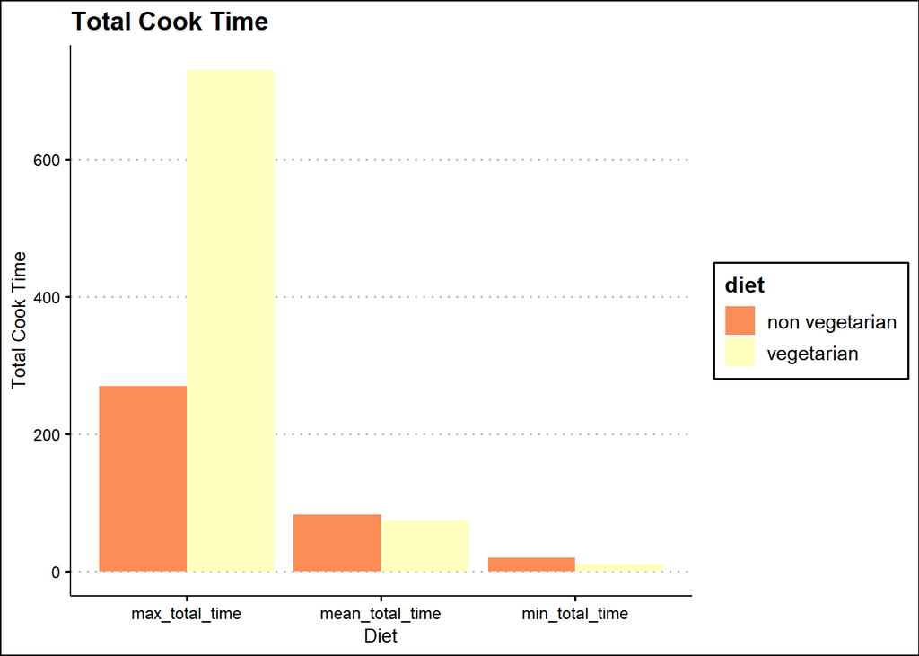

```r
v_nv_plot <- v_nv_long %>%
  ggplot(aes(x=time, y=cook_time, fill=diet))+geom_col(position = "dodge")
v_nv_plot + theme_clean()+scale_fill_brewer(palette = "Spectral")+labs(title="Total Cook Time", x="Diet", y="Total Cook Time")
```

2. For each diet, vegetarian and non-vegetarian, identify which dish takes the most and least amount of total cook time, prep time, and cook time. ELLYN

```r
indian_food_together %>%
  filter(diet == "non vegetarian") %>%
  filter(total_cook_time == 20)
```

| name | ingredients | diet | prep_time | cook_time | flavor_profile | course | state | region | total_cook_time |
| --- | --- | --- | --- | --- | --- | --- | --- | --- | --- |
| galho | rice, axone, salt, water, chillies, pork | non vegetarian | 5 | 15 | spicy | main course | nagaland | north east | 20 |

```r
indian_food_together %>%
  filter(diet == "non vegetarian") %>%
  filter(total_cook_time == 270)
```

| name | ingredients | diet | prep_time | cook_time | flavor_profile | course | state | region | total_cook_time |
| --- | --- | --- | --- | --- | --- | --- | --- | --- | --- |
| tandoori chicken | greek yogurt, garam masala, kasuri methi, marinade, mustard oil | non vegetarian | 240 | 30 | spicy | main course | punjab | north | 270 |
| tandoori fish tikka | chickpea flour, biryani masala powder, yogurt, fish fillets, green bell pepper | non vegetarian | 240 | 30 | spicy | starter | punjab | north | 270 |

```r
indian_food_together %>%
  filter(diet == "vegetarian") %>%
  filter(total_cook_time == 730)
```

| name | ingredients | diet | prep_time | cook_time | flavor_profile | course | state | region | total_cook_time |
| --- | --- | --- | --- | --- | --- | --- | --- | --- | --- |
| shrikhand | curd, sugar, saffron, cardamom | vegetarian | 10 | 720 | sweet | dessert | maharashtra | west | 730 |

```r
indian_food_together %>%
 filter(diet == "vegetarian") %>%
  filter(total_cook_time == 10)
```

| name | ingredients | diet | prep_time | cook_time | flavor_profile | course | state | region | total_cook_time |
| --- | --- | --- | --- | --- | --- | --- | --- | --- | --- |
| lassi | yogurt, milk, nuts, sugar | vegetarian | 5 | 5 | sweet | dessert | punjab | north | 10 |
| papad | urad dal, sev, lemon juice, chopped tomatoes | vegetarian | 5 | 5 | spicy | snack | NA | NA | 10 |
| papadum | lentils, black pepper, vegetable oil | vegetarian | 5 | 5 | spicy | snack | kerala | south | 10 |

3. What is the relationship between flavor and diet (i.e. is there more spicy dishes in non-vegetarian compared to vegetarian?) RACHEL

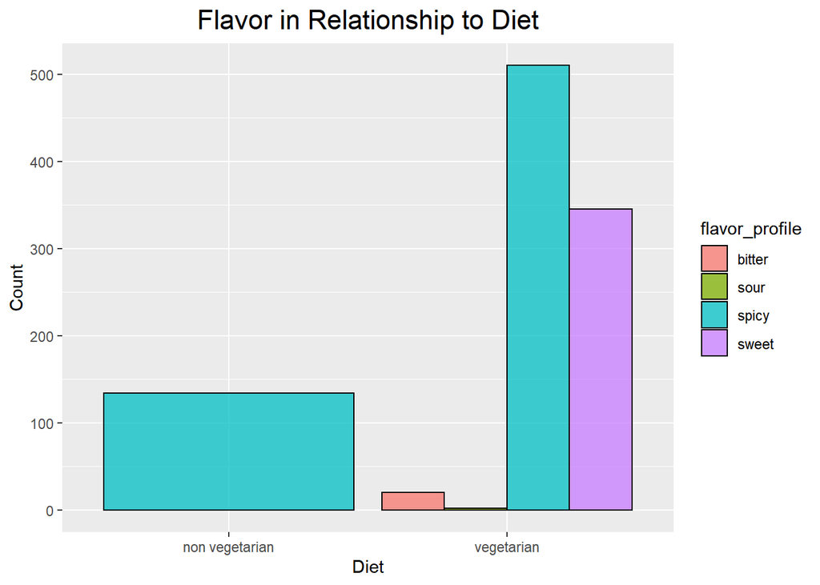

```r
flavor_diet <- indian_food %>%
  filter(!is.na(flavor_profile)) %>%
  ggplot(aes(x=diet, fill=flavor_profile))+
  geom_bar(na.rm=T, position="dodge",alpha=0.75, color="black") +
  labs(title = "Flavor in Relationship to Diet",
       x = "Diet",
       y = "Count") +
  theme(plot.title = element_text(size = rel(1.5), hjust = 0.5))
flavor_diet
```

4. Which ingredient is used the most for each region? EMILY

```r
indian_food%>%
  select(region, ingredients)%>%
  group_by(region)%>%
  count(ingredients)%>%
  arrange(desc(n))%>%
  filter(region=="central")
```

| region | ingredients | n |
| --- | --- | --- |
| central | all purpose flour | 1 |
| central | arhar dal | 1 |
| central | arrowroot powder | 1 |
| central | clarified butter | 1 |
| central | dry fruits | 1 |
| central | dry roasted | 1 |
| central | garam masala powder | 1 |
| central | jaggery | 1 |
| central | white urad dal | 1 |
| central | whole wheat flour | 1 |

[output cut: 3 more lines]

```r
indian_food%>%
  select(state, ingredients)%>%
  group_by(state)%>%
  count(ingredients)%>%
  arrange(desc(n))
```

| state | ingredients | n |
| --- | --- | --- |
| punjab | garam masala | 19 |
| west bengal | sugar | 10 |
| tamil nadu | curry leaves | 9 |
| assam | mustard oil | 8 |
| punjab | ginger | 7 |
| gujarat | bengal gram flour | 6 |
| gujarat | sugar | 6 |
| tamil nadu | urad dal | 6 |
| NA | ginger | 6 |
| NA | sugar | 6 |

[output cut: 829 more lines]

5. What ingredient is used the most out of all the courses? EMILY

```r
indian_food%>%
  select(ingredients,name)%>%
  count(ingredients)%>%
  arrange(desc(n))%>%
  head(n=5)
```

| ingredients | n |
| --- | --- |
| sugar | 45 |
| ginger | 29 |
| garam masala | 27 |
| curry leaves | 25 |
| ghee | 25 |

6. What diet is more associated with which region/state? GABE

```r
diet_region<-indian_food%>%
select("region", "diet")%>%
  filter(!is.na(region))
  #count(region, diet)%>%
  #arrange(desc(n))
diet_region
```

| region | diet |
| --- | --- |
| east | vegetarian |
| east | vegetarian |
| east | vegetarian |
| east | vegetarian |
| west | vegetarian |
| west | vegetarian |
| west | vegetarian |
| north | vegetarian |
| north | vegetarian |
| north | vegetarian |

[output cut: 1062 more lines]

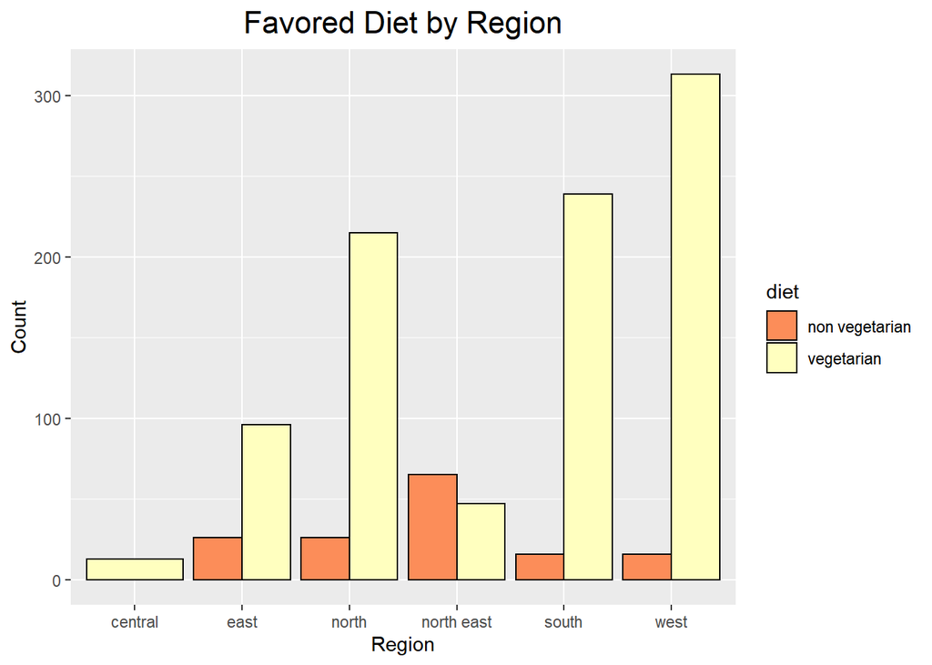

```r
diet_region%>%
 ggplot(aes(x=region, fill=diet))+
  geom_bar(na.rm=T, position="dodge", color="black") +
  labs(title = "Favored Diet by Region",
       x = "Region",
       y = "Count") +
  theme(plot.title = element_text(size = rel(1.5), hjust = 0.5))+
   theme(axis.text.x = element_text(hjust = 0.5))+
  scale_fill_brewer(palette="Spectral")
```

7. What flavor profile is more associated with which region/state? EMILY

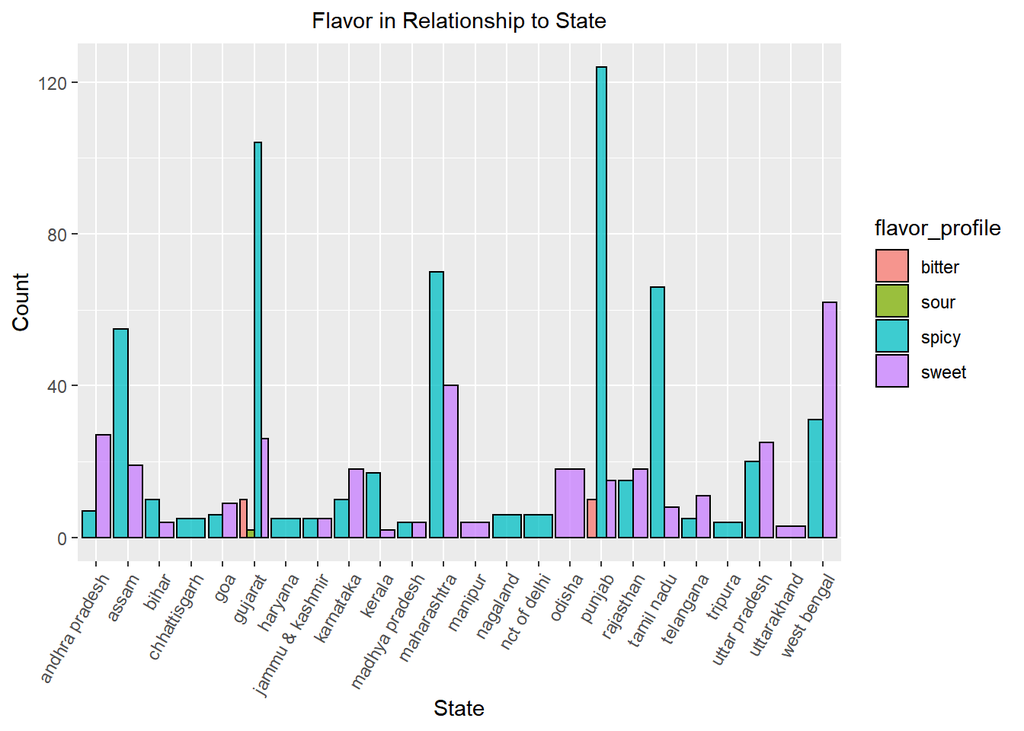

```r
flavor_state <- indian_food %>%
  filter(!is.na(flavor_profile)) %>%
  filter(!is.na(state)) %>%
  ggplot(aes(x=state, fill=flavor_profile))+
  geom_bar(na.rm=T, position="dodge",alpha=0.75, color="black") +
  labs(title = "Flavor in Relationship to State",
       x = "State",
       y = "Count") +
  theme(plot.title = element_text(size = rel(1.0), hjust = 0.5))+
   theme(axis.text.x = element_text(angle = 60, hjust = 1))
flavor_state
```

8. What is the population growth, GDP growth, and life expectancy of India (use gapminder data)? GABE

```r
gapminder
```

| country | continent | year | lifeExp | pop | gdpPercap |
| --- | --- | --- | --- | --- | --- |
| Afghanistan | Asia | 1952 | 28.80100 | 8425333 | 779.4453 |
| Afghanistan | Asia | 1957 | 30.33200 | 9240934 | 820.8530 |
| Afghanistan | Asia | 1962 | 31.99700 | 10267083 | 853.1007 |
| Afghanistan | Asia | 1967 | 34.02000 | 11537966 | 836.1971 |
| Afghanistan | Asia | 1972 | 36.08800 | 13079460 | 739.9811 |
| Afghanistan | Asia | 1977 | 38.43800 | 14880372 | 786.1134 |
| Afghanistan | Asia | 1982 | 39.85400 | 12881816 | 978.0114 |
| Afghanistan | Asia | 1987 | 40.82200 | 13867957 | 852.3959 |
| Afghanistan | Asia | 1992 | 41.67400 | 16317921 | 649.3414 |
| Afghanistan | Asia | 1997 | 41.76300 | 22227415 | 635.3414 |

[output cut: 1694 more lines]

```r
india_gapminder<-gapminder%>%
filter(country=="India")
india_gapminder
```

| country | continent | year | lifeExp | pop | gdpPercap |
| --- | --- | --- | --- | --- | --- |
| India | Asia | 1952 | 37.373 | 372000000 | 546.5657 |
| India | Asia | 1957 | 40.249 | 409000000 | 590.0620 |
| India | Asia | 1962 | 43.605 | 454000000 | 658.3472 |
| India | Asia | 1967 | 47.193 | 506000000 | 700.7706 |
| India | Asia | 1972 | 50.651 | 567000000 | 724.0325 |
| India | Asia | 1977 | 54.208 | 634000000 | 813.3373 |
| India | Asia | 1982 | 56.596 | 708000000 | 855.7235 |
| India | Asia | 1987 | 58.553 | 788000000 | 976.5127 |
| India | Asia | 1992 | 60.223 | 872000000 | 1164.4068 |
| India | Asia | 1997 | 61.765 | 959000000 | 1458.8174 |

[output cut: 2 more lines]

```r
ui <- dashboardPage(
  dashboardHeader(title = "India Gapminder"),
  dashboardSidebar(disable = T),
  dashboardBody(
    fluidRow(box(title = "Options", width = 5,
               selectInput("y", "Information", choices = c("lifeExp","pop","gdpPercap"), selected = "lifeExp")
               ),
  plotOutput("plot", width = "650px", height = "550px"))
    )
)


server <- function(input, output, session) {
  output$plot <- renderPlot({
  india_gapminder%>%
  ggplot(aes_string(x=india_gapminder$year, y=input$y, group=1))+
  geom_line()+
  theme(axis.text.x = element_text( hjust = 0.5, size = 12))+
      labs( title = "Background Information on India",
       x ="Year",
       y= NULL,
       fill= "Information")
  })
}
shinyApp(ui, server)
```

Shiny applications not supported in static R Markdown documents

9. What is the distribution of courses (e.g. main courses, snacks, dessert)? EMILY

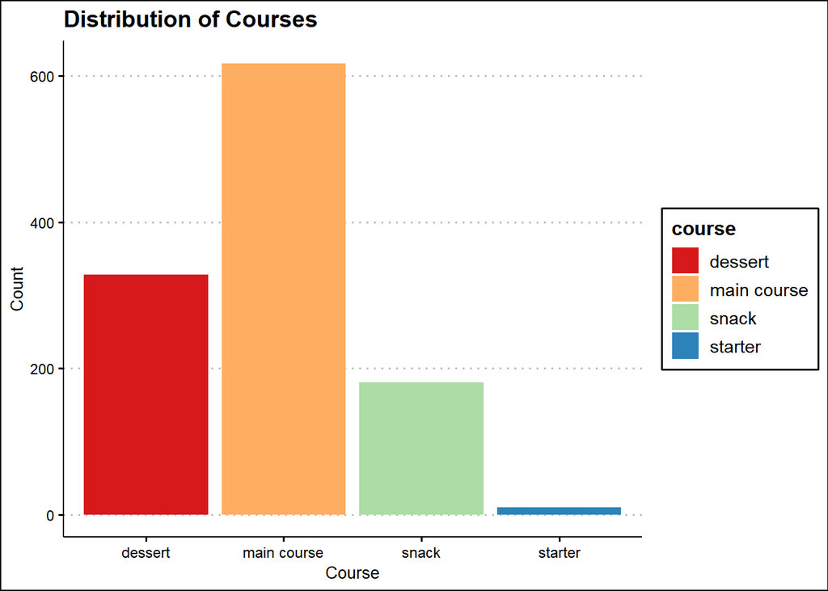

```r
indian_food%>%
  ggplot(aes(x=course, fill=course))+geom_bar()+theme_clean()+scale_fill_brewer(palette = "Spectral")+labs(title="Distribution of Courses", x="Course", y="Count")
```

10. Does agriculture by region have an impact on diet? Ellyn

## We started by uploading the data on agriculture and cleaning it up.

```r
agriculture <-  read_csv(here("agriculture.csv"))%>% clean_names()
agriculture <- agriculture %>%
  mutate_all(tolower)

agriculture <- agriculture %>%
  select("crop", "state")

agriculture
```

| crop | state |
| --- | --- |
| arhar | uttar pradesh |
| arhar | karnataka |
| arhar | gujarat |
| arhar | andhra pradesh |
| arhar | maharashtra |
| cotton | maharashtra |
| cotton | punjab |
| cotton | andhra pradesh |
| cotton | gujarat |
| cotton | haryana |

[output cut: 39 more lines]

```r
agr_diet <- full_join(indian_food_together, agriculture, by="state")
agr_diet
```

| name | ingredients | diet | prep_time | cook_time | flavor_profile | course | state | region | total_cook_time | crop |
| --- | --- | --- | --- | --- | --- | --- | --- | --- | --- | --- |
| balu shahi | maida flour, yogurt, oil, sugar | vegetarian | 45 | 25 | sweet | dessert | west bengal | east | 70 | paddy |
| boondi | gram flour, ghee, sugar | vegetarian | 80 | 30 | sweet | dessert | rajasthan | west | 110 | gram |
| boondi | gram flour, ghee, sugar | vegetarian | 80 | 30 | sweet | dessert | rajasthan | west | 110 | maize |
| boondi | gram flour, ghee, sugar | vegetarian | 80 | 30 | sweet | dessert | rajasthan | west | 110 | moong |
| boondi | gram flour, ghee, sugar | vegetarian | 80 | 30 | sweet | dessert | rajasthan | west | 110 | rapeseed and mustard |
| boondi | gram flour, ghee, sugar | vegetarian | 80 | 30 | sweet | dessert | rajasthan | west | 110 | wheat |
| gajar ka halwa | carrots, milk, sugar, ghee, cashews, raisins | vegetarian | 15 | 60 | sweet | dessert | punjab | north | 75 | cotton |
| gajar ka halwa | carrots, milk, sugar, ghee, cashews, raisins | vegetarian | 15 | 60 | sweet | dessert | punjab | north | 75 | paddy |
| gajar ka halwa | carrots, milk, sugar, ghee, cashews, raisins | vegetarian | 15 | 60 | sweet | dessert | punjab | north | 75 | wheat |
| ghevar | flour, ghee, kewra, milk, clarified butter, sugar, almonds, pistachio, saffron, green cardamom | vegetarian | 15 | 30 | sweet | dessert | rajasthan | west | 45 | gram |

[output cut: 763 more lines]

## Does the specialty crop have an impact on the total cook time?

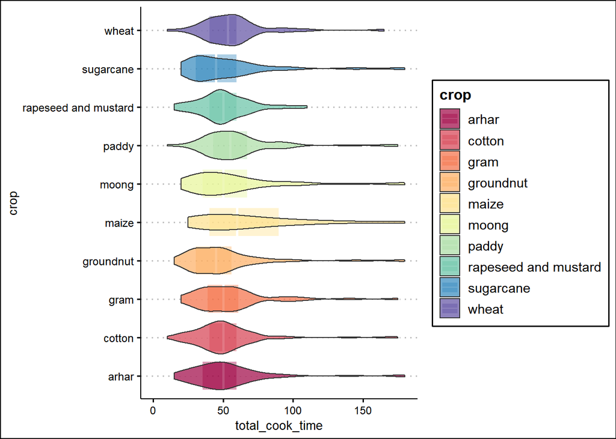

```r
agr_diet_plot <- agr_diet %>%
 filter(crop!="NA") %>%
  filter(total_cook_time!="NA") %>%
  ggplot(aes(x=crop, y=total_cook_time, fill=crop))+geom_boxplot(color="white", alpha=.4, na.rm = TRUE)+
  geom_violin(alpha=.7, na.rm=TRUE)+ ylim(0,180)+coord_flip()
agr_diet_plot+theme_clean()+scale_fill_brewer(palette = "Spectral")
```

**Shiny App EMILY

```r
library(shiny)
library(DT)
```

```r
library(ggplot2)

ui <- fluidPage(
  titlePanel("Welcome to the Indian Food E-Cookbook"),
  sidebarLayout(
    sidebarPanel(
      checkboxGroupInput("show_vars", "Select What You Want To Find", names(indian_food), selected=names(indian_food))
    ), helpText("Welcome to the Indian Food E-Cookbook! Indian cuisine consists of a variety of regional and traditional cuisines native to the Indian subcontinent. Given the diversity in soil, climate, culture, ethnic groups, and occupations, these cuisines vary substantially and use locally available spices, herbs, vegetables, and fruits. Indian food is also heavily influenced by religion, in particular Hinduism, cultural choices and traditions.

This dataset consists of information about various Indian dishes, their ingredients, their place of origin, etc.

Reference: Neha Prabhavalkar [https://www.kaggle.com/nehaprabhavalkar/indian-food-101]")),
  mainPanel(
    id='indian_food',
    tabPanel("indian food", DT::dataTableOutput("mytable"))
  )
)


server <- function(input, output) {
  indian_food=indian_food[sample(nrow(indian_food), 1136),]
  output$mytable = DT::renderDataTable({
    DT::datatable(indian_food[,input$show_vars, drop=FALSE], options=list(orderClasses=TRUE))
  })
}

shinyApp(ui,server)
```

Shiny applications not supported in static R Markdown documents